# Lab 2

```python
#0. Import the data and declare your package dependencies.

import pandas as pd
df = pd.read_csv("avocado-updated-2020.csv")
df
```

|  | date | average_price | total_volume | 4046 | 4225 | 4770 | total_bags | small_bags | large_bags | xlarge_bags | type | year | geography |
| --- | --- | --- | --- | --- | --- | --- | --- | --- | --- | --- | --- | --- | --- |
| 0 | 2015-01-04 | 1.22 | 40873.28 | 2819.50 | 28287.42 | 49.90 | 9716.46 | 9186.93 | 529.53 | 0.00 | conventional | 2015 | Albany |
| 1 | 2015-01-04 | 1.79 | 1373.95 | 57.42 | 153.88 | 0.00 | 1162.65 | 1162.65 | 0.00 | 0.00 | organic | 2015 | Albany |
| 2 | 2015-01-04 | 1.00 | 435021.49 | 364302.39 | 23821.16 | 82.15 | 46815.79 | 16707.15 | 30108.64 | 0.00 | conventional | 2015 | Atlanta |
| 3 | 2015-01-04 | 1.76 | 3846.69 | 1500.15 | 938.35 | 0.00 | 1408.19 | 1071.35 | 336.84 | 0.00 | organic | 2015 | Atlanta |
| 4 | 2015-01-04 | 1.08 | 788025.06 | 53987.31 | 552906.04 | 39995.03 | 141136.68 | 137146.07 | 3990.61 | 0.00 | conventional | 2015 | Baltimore/Washington |
| ... | ... | ... | ... | ... | ... | ... | ... | ... | ... | ... | ... | ... | ... |
| 33040 | 2020-11-29 | 1.47 | 1583056.27 | 67544.48 | 97996.46 | 2617.17 | 1414878.10 | 906711.52 | 480191.83 | 27974.75 | organic | 2020 | Total U.S. |
| 33041 | 2020-11-29 | 0.91 | 5811114.22 | 1352877.53 | 589061.83 | 19741.90 | 3790665.29 | 2197611.02 | 1531530.14 | 61524.13 | conventional | 2020 | West |
| 33042 | 2020-11-29 | 1.48 | 289961.27 | 13273.75 | 19341.09 | 636.51 | 256709.92 | 122606.21 | 134103.71 | 0.00 | organic | 2020 | West |
| 33043 | 2020-11-29 | 0.67 | 822818.75 | 234688.01 | 80205.15 | 10543.63 | 497381.96 | 285764.11 | 210808.02 | 809.83 | conventional | 2020 | West Tex/New Mexico |
| 33044 | 2020-11-29 | 1.35 | 24106.58 | 1236.96 | 617.80 | 1564.98 | 20686.84 | 17824.52 | 2862.32 | 0.00 | organic | 2020 | West Tex/New Mexico |

33045 rows × 13 columns

#1. Briefly describe the data set. What information does it contain?

The Avocado Prices dataset tracks avocado sales and prices from 2015-2020. It distingueshes between conventional and organic avocados and provides data by U.S. city/region.

There is 13 columns and 33’045 observations.

```python
# 2. Cleaning the data

df.isna().sum()
```

```
date             0
average_price    0
total_volume     0
4046             0
4225             0
4770             0
total_bags       0
small_bags       0
large_bags       0
xlarge_bags      0
type             0
year             0
geography        0
dtype: int64
```

Output shows we have zero missing values.

```python
#2. Cleaning data
df['geography'].nunique()
```

```
54
```

```python
#2. Cleaning data
df['geography'].unique()
```

```
array(['Albany', 'Atlanta', 'Baltimore/Washington', 'Boise', 'Boston',
       'Buffalo/Rochester', 'California', 'Charlotte', 'Chicago',
       'Cincinnati/Dayton', 'Columbus', 'Dallas/Ft. Worth', 'Denver',
       'Detroit', 'Grand Rapids', 'Great Lakes', 'Harrisburg/Scranton',
       'Hartford/Springfield', 'Houston', 'Indianapolis', 'Jacksonville',
       'Las Vegas', 'Los Angeles', 'Louisville', 'Miami/Ft. Lauderdale',
       'Midsouth', 'Nashville', 'New Orleans/Mobile', 'New York',
       'Northeast', 'Northern New England', 'Orlando', 'Philadelphia',
       'Phoenix/Tucson', 'Pittsburgh', 'Plains', 'Portland',
       'Raleigh/Greensboro', 'Richmond/Norfolk', 'Roanoke', 'Sacramento',
       'San Diego', 'San Francisco', 'Seattle', 'South Carolina',
       'South Central', 'Southeast', 'Spokane', 'St. Louis', 'Syracuse',
       'Tampa', 'Total U.S.', 'West', 'West Tex/New Mexico'], dtype=object)
```

So we have 54 region names. Some like Los Angeles is contained in California which is contained in West which is contained in Total U.S. Therefore, we need to label regions by its size to avoid double count.

```python
#2. Cleaning data (labeling regions by its size, chatgpt helped here)
national = ['Total U.S.']
major_regions = ['West', 'Northeast', 'South Central', 'Southeast', 'Plains', 'Great Lakes', 'Midsouth']
states = ['California', 'Texas', 'Florida', 'New York', 'South Carolina']

def categorize(region):
    if region in national:
        return 'national'
    elif region in major_regions:
        return 'major_region'
    elif region in states:
        return 'state'
    else:
        return 'metro'

df['geo_type'] = df['geography'].apply(categorize)
```

```python
#2. double check my region output to see if I labeled everything correctly
df.groupby('geo_type')['geography'].nunique()
```

```
geo_type
major_region     7
metro           43
national         1
state            3
Name: geography, dtype: int64
```

```python
#2. Cleaning data (creating seperate datasets for easier access later)
# Major region–level data
df_major = df[df['geo_type'] == 'major_region']

# Metro-level data
df_metro = df[df['geo_type'] == 'metro']

# California-only metro regions
df_ca = df[df['geography'].isin(['Los Angeles','San Diego','Sacramento','San Francisco'])]
```

```python
#2. Cleaning data (converting date from a string into an actual datetime type so that pandas can understand it)

# Convert 'date' column to proper datetime format
df['date'] = pd.to_datetime(df['date'])

# Extract year, month, and day into new columns
df['year'] = df['date'].dt.year
df['month'] = df['date'].dt.month
df['day'] = df['date'].dt.day

# Check to confirm if it worked
df[['date', 'year', 'month', 'day']].head()
```

|  | date | year | month | day |
| --- | --- | --- | --- | --- |
| 0 | 2015-01-04 | 2015 | 1 | 4 |
| 1 | 2015-01-04 | 2015 | 1 | 4 |
| 2 | 2015-01-04 | 2015 | 1 | 4 |
| 3 | 2015-01-04 | 2015 | 1 | 4 |
| 4 | 2015-01-04 | 2015 | 1 | 4 |

```python
#2. Cleaning Data (Rename confusing columns)
df = df.rename(columns={
    '4046': 'small_avocados',
    '4225': 'large_avocados',
    '4770': 'xlarge_avocados'
})

# Check if the renaming worked
print(df.columns)
```

```
Index(['date', 'average_price', 'total_volume', 'small_avocados',
       'large_avocados', 'xlarge_avocados', 'total_bags', 'small_bags',
       'large_bags', 'xlarge_bags', 'type', 'year', 'geography', 'geo_type',
       'month', 'day'],
      dtype='object')
```

```python
#2. Cleaning Data (Round all avocado quantity columns to the nearest integer)

cols_to_round = [
    'small_avocados', 'large_avocados', 'xlarge_avocados',
    'total_bags', 'small_bags', 'large_bags'
]

df[cols_to_round] = df[cols_to_round].round(0).astype(int)

# Verify if the rounding worked
df[cols_to_round].head()

#cols_to_round = List of columns you want to round
#.round(0) = rounds all numeric values to 0 decimals places (nearest integer)
#.astype(int) = converts the results into integers
```

|  | small_avocados | large_avocados | xlarge_avocados | total_bags | small_bags | large_bags |
| --- | --- | --- | --- | --- | --- | --- |
| 0 | 2820 | 28287 | 50 | 9716 | 9187 | 530 |
| 1 | 57 | 154 | 0 | 1163 | 1163 | 0 |
| 2 | 364302 | 23821 | 82 | 46816 | 16707 | 30109 |
| 3 | 1500 | 938 | 0 | 1408 | 1071 | 337 |
| 4 | 53987 | 552906 | 39995 | 141137 | 137146 | 3991 |

```python
avocado_clean = df
```

```python
# Q3: Which major geographical region sold the most total organic, small Hass avocados in 2017? (chat helped)

Q3_region_sales = (
    avocado_clean[
        (avocado_clean['geo_type'] == 'major_region') &
        (avocado_clean['type'] == 'organic') &
        (avocado_clean['year'] == 2017)
    ]
    .groupby('geography')['small_avocados']
    .sum()
    .sort_values(ascending=False)
)
Q3_region_sales
#sort by only 'geo_type' = so we count avocados sold in major regions
#sort by 'type' = so we count the organic avocados sold
#sort by 'year' = so we count avocados sold in year 2017
#groupby = we group by region
#sum = add these values up
#.sort_values(ascending=False) = sort from highest to lowest
# In 2017 most organic small avocados where sold in the West Region
```

```
geography
West             1870205
South Central    1717102
Northeast         925832
Southeast         285126
Great Lakes       202488
Midsouth          186401
Plains            168583
Name: small_avocados, dtype: int64
```

```python
#Q4. In which month is the highest average volume of avocado sales?

Q4_highest_sale_month = (
    avocado_clean
    .groupby('month')['total_volume']
    .mean()
    .sort_values(ascending=False)
)
Q4_highest_sale_month = Q4_highest_sale_month.round(0).astype(int)
Q4_highest_sale_month
#groupby = we group the total volume of avocado sales by months
#mean() = averages the avocado sales
#.sort_values(ascending=False) = sort from highest to lowest
#then Chatgpt helped me change the ouput numbers to round and convert to the nearest integer
#therefore we see we have the highes avg sale of avocados in month May
```

```
month
5     1123632
2     1095374
6     1051247
4     1016582
3      995715
1      985312
7      983268
8      949925
9      906477
10     844686
11     822347
12     807669
Name: total_volume, dtype: int64
```

```python
#Q5. Which metro area geographical regions sold the most total avocados?
# Plot side-by-side box-plots of the total volume for only the five metro geographical regions with the highest averages for the total_volume variable.

df_metro = avocado_clean[avocado_clean['geo_type'] == 'metro']
# Similar to Q4, We sort the highest avg sale of avocados but by Metro now and not month
#head(5) gives us only the five highest averages
Top_5_metros = (
    df_metro.groupby('geography')['total_volume']
    .mean()
    .sort_values(ascending=False)
    .head(5)
)
# Same as Q4 we round and convert to integers for a cleaner output
Top_5_metros = Top_5_metros.round(0).astype(int)
Top_5_metros

df_Top_5 = df_metro[df_metro['geography'].isin(Top_5_metros.index)]
```

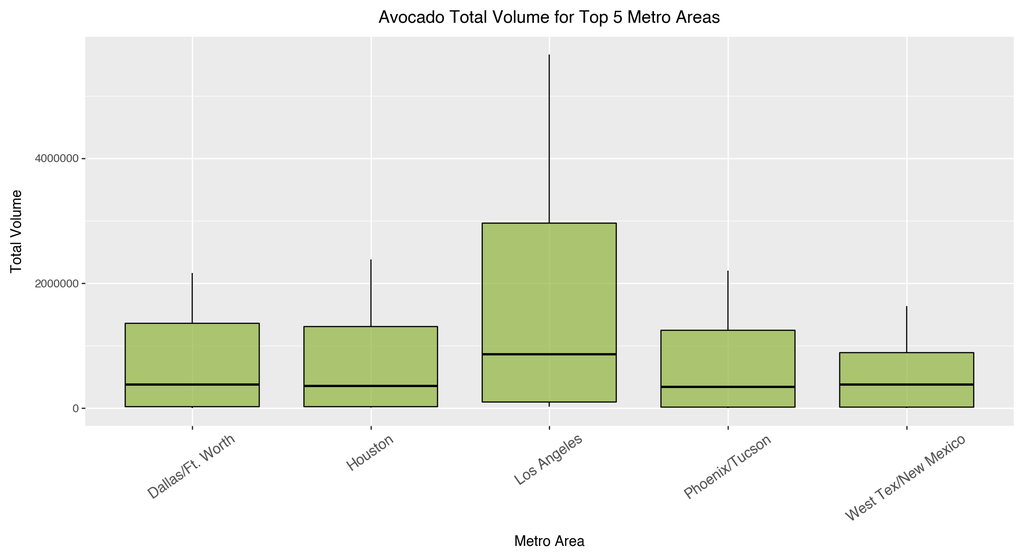

```python
#Import plotnine to create the graph:
from plotnine import ggplot, aes, geom_boxplot, labs, theme, element_text

#Creating plot (like in Lab1)(used chat to find avocado green color and adjust the sizes of the graph)
(
    ggplot(df_Top_5, aes(x='geography', y='total_volume'))
    + geom_boxplot(fill="#8FB339", color="black", alpha = 0.7)
    + labs(
        title="Avocado Total Volume for Top 5 Metro Areas",
        x="Metro Area",
        y="Total Volume"
    )
    + theme(
        axis_text_x=element_text(size=11, rotation=35),
        figure_size=(11, 6)
    )
)
```

```python
#Q6. From your cleaned data set, create a data set with only these California regions and answer the following questions about these California regions only.
#When cleaning my data I already created a seperate dataset for the four california-only metro regions
#to check if our data set is correct and still here we use:

df_ca['geography'].unique()
```

```
array(['Los Angeles', 'Sacramento', 'San Diego', 'San Francisco'],
      dtype=object)
```

```python
#Q7. In which California regions is the price of organic versus conventional avocados most different?
#lets compare average prices between organic and conventional avocados by the four california regions.

price_summary = (
    df_ca.groupby(['geography', 'type'])['average_price']
    .mean()
    .unstack()
    .round(2)
)
price_summary['difference'] = (
    price_summary['organic'] - price_summary['conventional']
).round(2)

price_summary.sort_values('difference', ascending=False)

#.unstack() “spreads” the type values (conventional, organic) into columns it’s like a quick pivot.
#round(2) rounds the resulting averages to 2 decimal places.
```

| type geography | conventional | organic | difference |
| --- | --- | --- | --- |
| San Francisco | 1.40 | 2.12 | 0.72 |
| San Diego | 1.11 | 1.80 | 0.69 |
| Sacramento | 1.30 | 1.87 | 0.57 |
| Los Angeles | 1.05 | 1.57 | 0.52 |

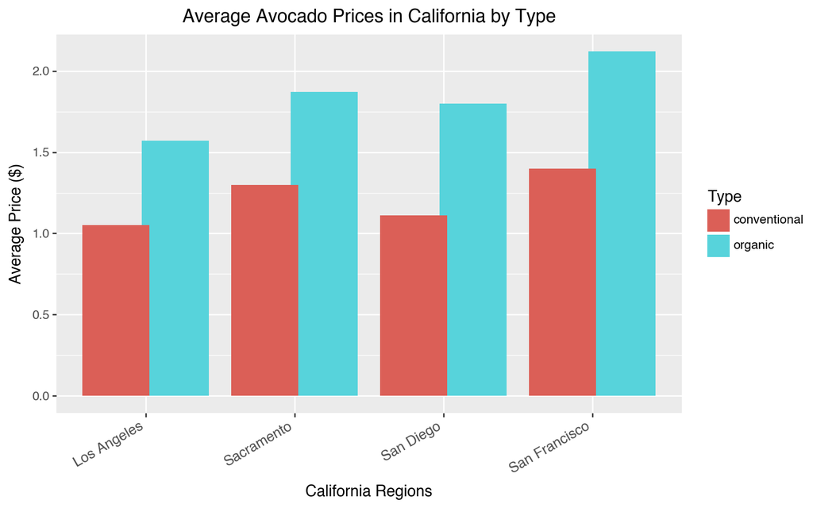

```python
#Q7. Create Visuals for showing the difference between organic and conventional avocado sales in California

from plotnine import ggplot, aes, geom_col, labs, theme, element_text, position_dodge

# Plot directly from grouped data
(
    ggplot(
        df_ca.groupby(['geography', 'type'], as_index=False)['average_price']
        .mean()
        .round(2),
        aes(x='geography', y='average_price', fill='type')
    )
    + geom_col(position=position_dodge(width=0.8))
    + labs(
        title='Average Avocado Prices in California by Type',
        x='California Regions',
        y='Average Price ($)',
        fill='Type'
    )
    + theme(
        figure_size=(8, 5),
        axis_text_x=element_text(rotation=30, size=10, ha='right'),
        plot_title=element_text(size=13, weight='bold', ha='center')
    )
)



#position_dodge controls how bars are placed next to each other in grouped bar charts.
#Without position_dodge, Bars for organic and conventional are stacked on top of each other
#With position_dodge(width=0.8), Bars are side by side, so you can compare them easily
#ha stands for horizontal alignment, it controls how text is positioned horizontally relative to its anchor point.
```

```python
df_ca = df_ca.rename(columns={
    '4046': 'small_avocados',
    '4225': 'large_avocados',
    '4770': 'xlarge_avocados'
})
df_ca.columns
```

```
Index(['date', 'average_price', 'total_volume', 'small_avocados',
       'large_avocados', 'xlarge_avocados', 'total_bags', 'small_bags',
       'large_bags', 'xlarge_bags', 'type', 'year', 'geography', 'geo_type'],
      dtype='object')
```